# One4All_LA9

Braden Griebel, Luke Fanning, Andrew Duffy, Ahyo Falick

10/23/2019

```r
factbook<-read_delim("factbook.csv",delim=";",col_types = cols(
  Country=col_character(),
  `Area(sq km)`=col_double(),
  `Birth rate(births/1000 population)`=col_double(),
  `Current account balance`=col_double(),
  `Death rate(deaths/1000 population)`=col_double(),
  `Debt - external`=col_double(),
  `Electricity - consumption(kWh)`=col_double(),
  `Electricity - production(kWh)`=col_double(),
  `Exports`=col_double(),
  `GDP`=col_double(),
  `GDP - per capita`=col_double(),
  `GDP - real growth rate(%)`=col_double(),
  `HIV/AIDS - adult prevalence rate(%)`=col_double(),
  `HIV/AIDS - deaths`=col_double(),
  `HIV/AIDS - people living with HIV/AIDS`=col_double(),
  `Highways(km)`=col_double(),
  `Imports`=col_double(),
  `Industrial production growth rate(%)`=col_double(),
  `Infant mortality rate(deaths/1000 live births)`=col_double(),
  `Inflation rate (consumer prices)(%)`=col_double(),
  `Internet hosts`=col_double(),
  `Internet users`=col_double(),
  `Investment (gross fixed)(% of GDP)`=col_double(),
  `Labor force`=col_double(),
  `Life expectancy at birth(years)`=col_double(),
  `Military expenditures - dollar figure`=col_double(),
  `Military expenditures - percent of GDP(%)`=col_double(),
  `Natural gas - consumption(cu m)`=col_double(),
  `Natural gas - exports(cu m)`=col_double(),
  `Natural gas - imports(cu m)`=col_double(),
  `Natural gas - production(cu m)`=col_double(),
  `Natural gas - proved reserves(cu m)`=col_double(),
  `Oil - consumption(bbl/day)`=col_double(),
  `Oil - exports(bbl/day)`=col_double(),
  `Oil - imports(bbl/day)`=col_double(),
  `Oil - production(bbl/day)`=col_double(),
  `Oil - proved reserves(bbl)`=col_double(),
  `Population`=col_double(),
  `Railways(km)`=col_double(),
  `Public debt(% of GDP)`=col_double(),
  `Reserves of foreign exchange & gold`=col_double(),
  `Telephones - main lines in use`=col_double(),
  `Telephones - mobile cellular`=col_double(),
  `Total fertility rate(children born/woman)`=col_double(),
  `Unemployment rate(%)`=col_double()
))
factbook<-factbook[2:264,]
colnames(factbook)
```

```
##  [1] "Country"
##  [2] "Area(sq km)"
##  [3] "Birth rate(births/1000 population)"
##  [4] "Current account balance"
##  [5] "Death rate(deaths/1000 population)"
##  [6] "Debt - external"
##  [7] "Electricity - consumption(kWh)"
##  [8] "Electricity - production(kWh)"
##  [9] "Exports"
## [10] "GDP"
## [11] "GDP - per capita"
## [12] "GDP - real growth rate(%)"
## [13] "HIV/AIDS - adult prevalence rate(%)"
## [14] "HIV/AIDS - deaths"
## [15] "HIV/AIDS - people living with HIV/AIDS"
```

[output cut: 30 more lines]

## Team Question

We were hired by an public health specialist to determine the relationship between the level of industrialization (measured by electricity, natural gas, and oil consumption as well as industrial production growth rate) and the various measures of population health, such as death rate, infant mortality and life expectancy. This will help illuminate the relationship between industrialization and health. Understanding this relationship will help to guide policies about how indistrialization is encouraged or discouraged in different areas in order to increase the general health of the populace. Obviously, a public health specialist would find this question extremely important in this day and age, as our world is becoming increasingly industrialized and reliant on production of various methods of power creation, and any positive or negative trend between levels of indutrialization and general population health could be extremely influential in determining which regions of industrial production and consumption should be supported and accelerated in developing and developed countries. These findings would also be incredibly influential in determining public policy in developed countries, as if any findings turn out to be conclusive, it is important that all government officials are aware so that the best policies can be put in place in order to both help the plant’s general health as well as each country’s general population health. However, without the help of a public health specialist, who has the power to work with lobbyists to make publicly elected officials aware of these issues, the data may simply fall on deaf ears and lead to little or no impact in governmental policymaking and decisions.

### Electricity Production

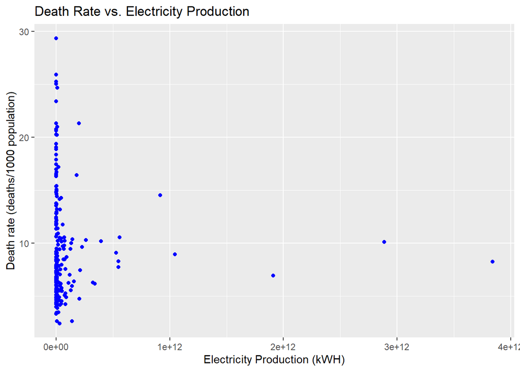

```r
factbook1_1 <- factbook %>% filter(!is.na(`Death rate(deaths/1000 population)`) & !is.na(`Electricity - production(kWh)`))
ggplot(data = factbook1_1) + geom_point(aes(x= `Electricity - production(kWh)`, y = `Death rate(deaths/1000 population)`), color = "blue") + labs(title = "Death Rate vs. Electricity Production", x = "Electricity Production (kWH)", y = "Death rate (deaths/1000 population)")
```

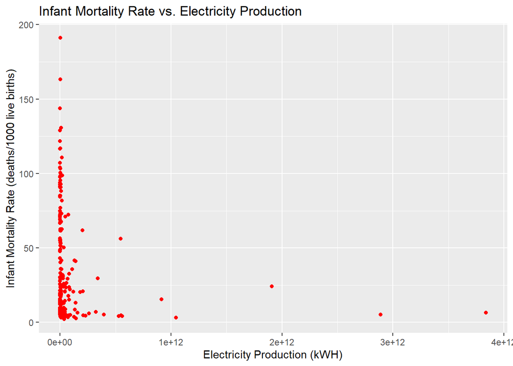

```r
factbook1_2 <- factbook %>% filter(!is.na(`Infant mortality rate(deaths/1000 live births)`) & !is.na(`Electricity - production(kWh)`))
ggplot(data = factbook1_2)+ geom_point(aes(x= `Electricity - production(kWh)`, y  = `Infant mortality rate(deaths/1000 live births)`), color = "red")+ labs(title = "Infant Mortality Rate vs. Electricity Production", x = "Electricity Production (kWH)", y = "Infant Mortality Rate (deaths/1000 live births)")
```

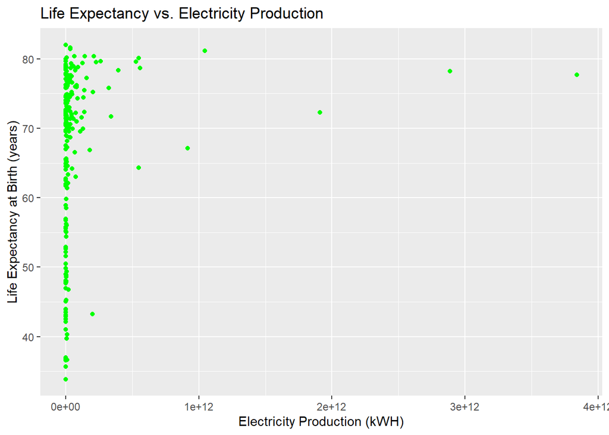

```r
factbook1_3 <- factbook %>% filter(!is.na(`Life expectancy at birth(years)`) & !is.na(`Electricity - production(kWh)`))
ggplot(data = factbook1_3)+ geom_point(aes(x= `Electricity - production(kWh)`, y  = `Life expectancy at birth(years)`), color = "green") + labs(title = "Life Expectancy vs. Electricity Production", x = "Electricity Production (kWH)", y = "Life Expectancy at Birth (years)")
```

### Electricity Consumption

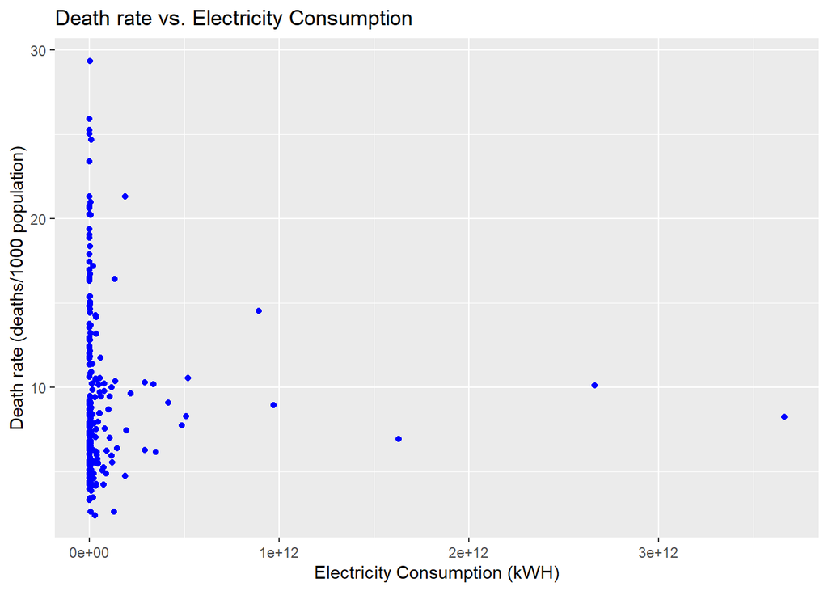

```r
factbook2_1 <- factbook %>% filter(!is.na(`Death rate(deaths/1000 population)`) & !is.na(`Electricity - consumption(kWh)`))
ggplot(data = factbook2_1) + geom_point(aes(x= `Electricity - consumption(kWh)`, y = `Death rate(deaths/1000 population)`), color = "blue") + labs(title = "Death rate vs. Electricity Consumption", x = "Electricity Consumption (kWH)", y = "Death rate (deaths/1000 population)")
```

[figure not shown]

```r
factbook2_2 <- factbook %>% filter( !is.na(`Infant mortality rate(deaths/1000 live births)`) & !is.na(`Electricity - consumption(kWh)`))
ggplot(data = factbook2_2)+ geom_point(aes(x= `Electricity - consumption(kWh)`, y  = `Infant mortality rate(deaths/1000 live births)`), color = "red") + labs(title = "Death rate vs. Electricity Consumption", x = "Electricity Consumption (kWH)", y = "Infant Mortality Rate (deaths/1000 live births)")
```

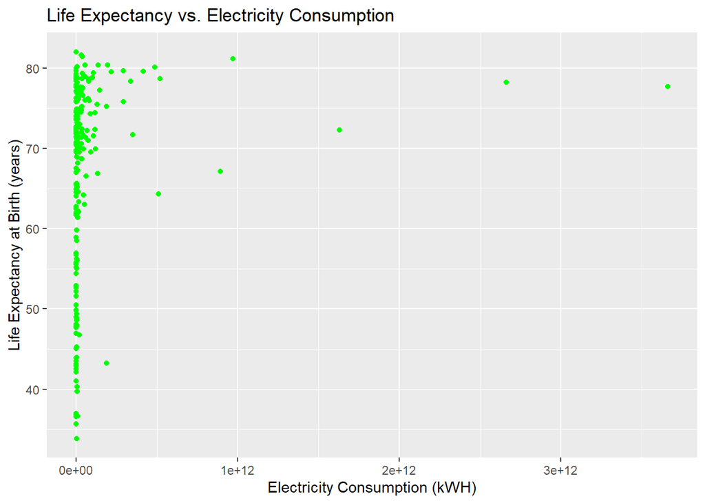

```r
factbook2_3 <- factbook %>% filter(!is.na(`Life expectancy at birth(years)`) & !is.na(`Electricity - consumption(kWh)`))
ggplot(data = factbook2_3)+ geom_point(aes(x= `Electricity - consumption(kWh)`, y  = `Life expectancy at birth(years)`), color = "green")+ labs(title = "Life Expectancy vs. Electricity Consumption", x = "Electricity Consumption (kWH)", y = "Life Expectancy at Birth (years)")
```

#### Findings: Electricity Production & Consumption

*As seen in the graphs above, there isn’t a large correlation between electrictiy prodcution and consumption vs. the three measures used above for displaying population health. For example, in terms of death rate per 1000 population, the death rate varies wildly along the y-axis, showing both the minimum death rate seen in the data with esentially 0 electricity production or consumption, as well as showing the maximum death rate seen in the data set, also at basically 0 electricity production and consumption. While the data does seem to display a positive trend towards increasing life expectancy and decreasing mortality rates as electricity production and consumption increases, due to the overwhelming lack of trend of data at 0 electricity production and consumption, it is virtually impossible to say whether this positive trend with increasing electricity rates is meaningful or just caused by other factors that were not accounted for in the above graphs.*

### Natural Gas Production

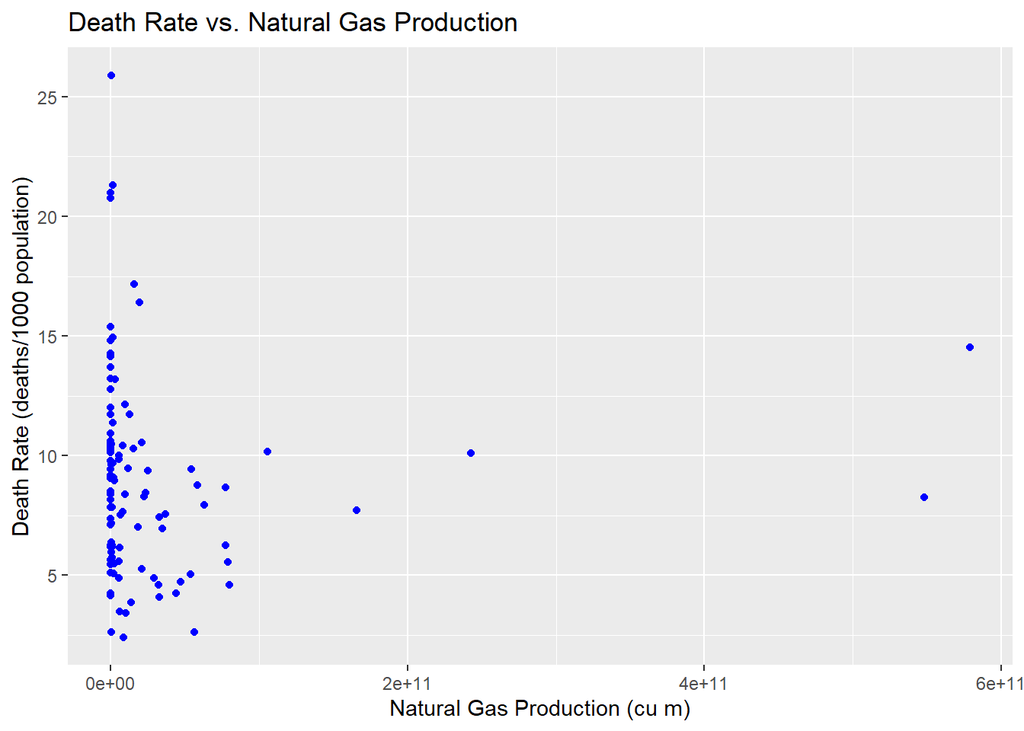

```r
factbook3_1 <- factbook %>% filter(!is.na(`Death rate(deaths/1000 population)`) & !is.na(`Natural gas - production(cu m)`))
ggplot(data = factbook3_1) + geom_point(aes(x= `Natural gas - production(cu m)`, y = `Death rate(deaths/1000 population)`), color = "blue") + labs(title = "Death Rate vs. Natural Gas Production", x = "Natural Gas Production (cu m)", y = "Death Rate (deaths/1000 population)")
```

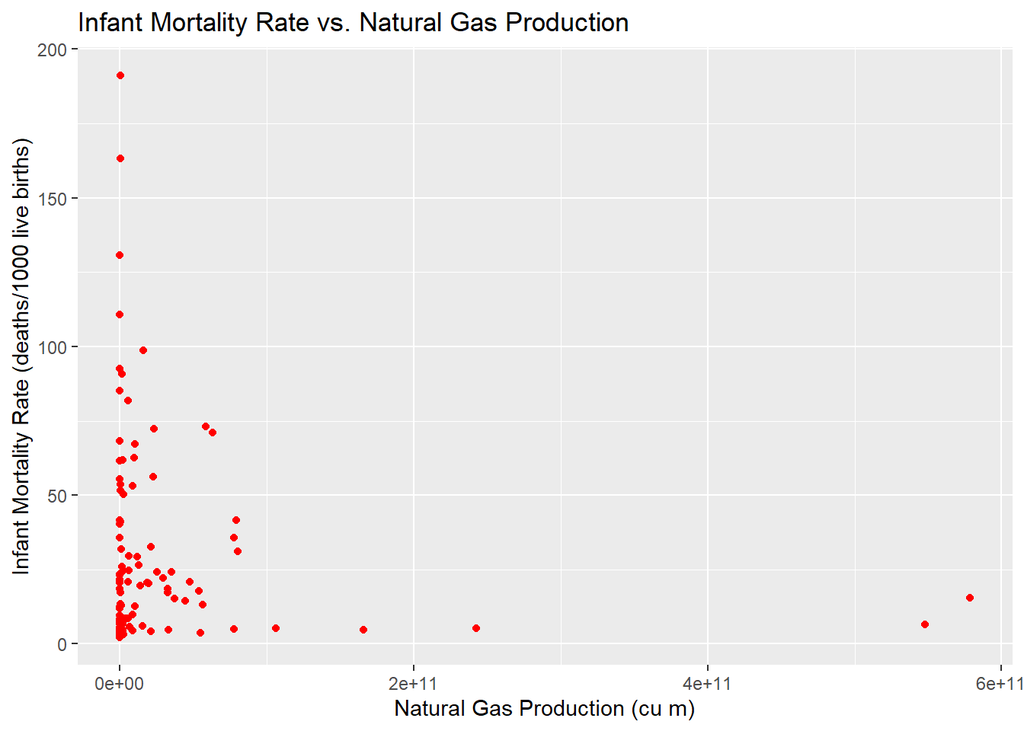

```r
factbook3_2 <- factbook %>% filter( !is.na(`Infant mortality rate(deaths/1000 live births)`) & !is.na(`Natural gas - production(cu m)`))
ggplot(data = factbook3_2) + geom_point(aes(x= `Natural gas - production(cu m)`, y  = `Infant mortality rate(deaths/1000 live births)`), color = "red") + labs(title = "Infant Mortality Rate vs. Natural Gas Production", x = "Natural Gas Production (cu m)", y = "Infant Mortality Rate (deaths/1000 live births)")
```

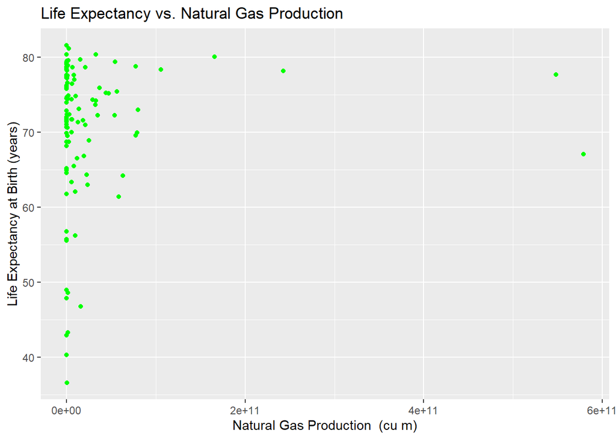

```r
factbook3_3 <- factbook %>% filter(!is.na(`Life expectancy at birth(years)`) & !is.na(`Natural gas - production(cu m)`))
ggplot(data = factbook3_3)+ geom_point(aes(x= `Natural gas - production(cu m)`, y  = `Life expectancy at birth(years)`), color = "green")+ labs(title = "Life Expectancy vs. Natural Gas Production", x = "Natural Gas Production  (cu m)", y = "Life Expectancy at Birth (years)")
```

### Natural Gas COnsumption

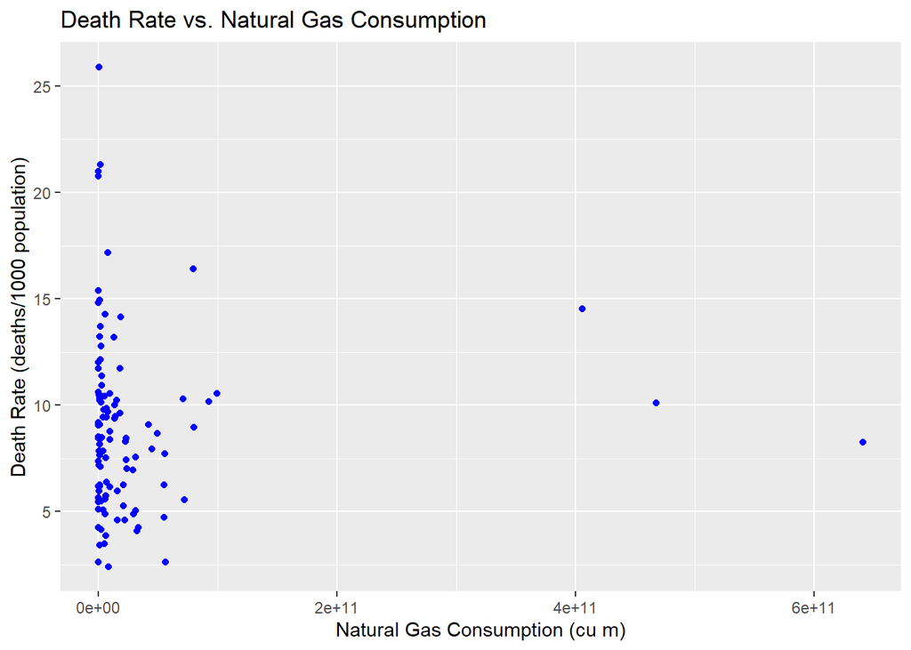

```r
factbook4_1 <- factbook %>% filter(!is.na(`Death rate(deaths/1000 population)`) & !is.na(`Natural gas - consumption(cu m)`))
ggplot(data = factbook4_1) + geom_point(aes(x= `Natural gas - consumption(cu m)`, y = `Death rate(deaths/1000 population)`), color = "blue") + labs(title = "Death Rate vs. Natural Gas Consumption", x = "Natural Gas Consumption (cu m)", y = "Death Rate (deaths/1000 population)")
```

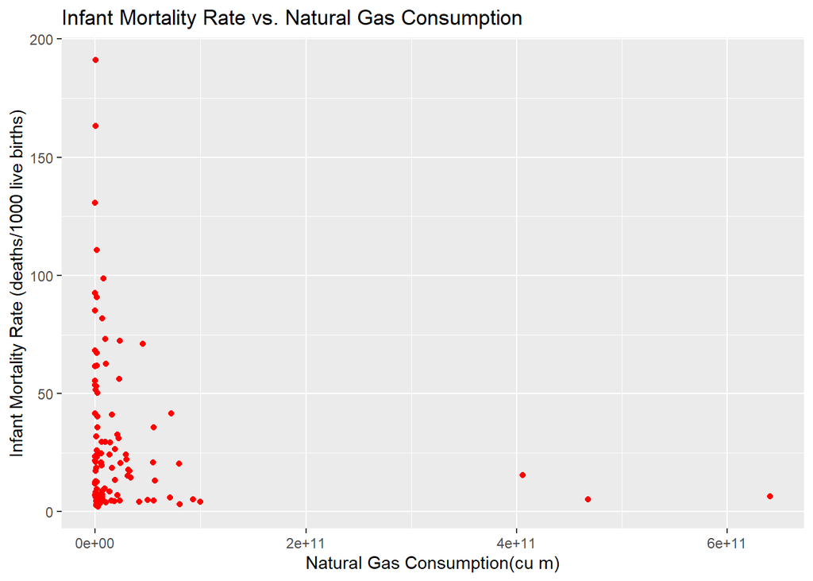

```r
factbook4_2 <- factbook %>% filter( !is.na(`Infant mortality rate(deaths/1000 live births)`) & !is.na(`Natural gas - consumption(cu m)`))
ggplot(data = factbook4_2) + geom_point(aes(x= `Natural gas - consumption(cu m)`, y  = `Infant mortality rate(deaths/1000 live births)`), color = "red") + labs(title = "Infant Mortality Rate vs. Natural Gas Consumption", x = "Natural Gas Consumption(cu m)", y = "Infant Mortality Rate (deaths/1000 live births)")
```

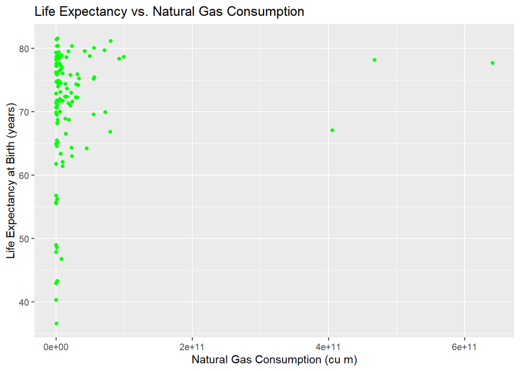

```r
factbook4_3 <- factbook %>% filter(!is.na(`Life expectancy at birth(years)`) & !is.na(`Natural gas - consumption(cu m)`))
ggplot(data = factbook4_3)+ geom_point(aes(x= `Natural gas - consumption(cu m)`, y  = `Life expectancy at birth(years)`), color = "green")+ labs(title = "Life Expectancy vs. Natural Gas Consumption", x = "Natural Gas Consumption (cu m)", y = "Life Expectancy at Birth (years)")
```

### Oil Production

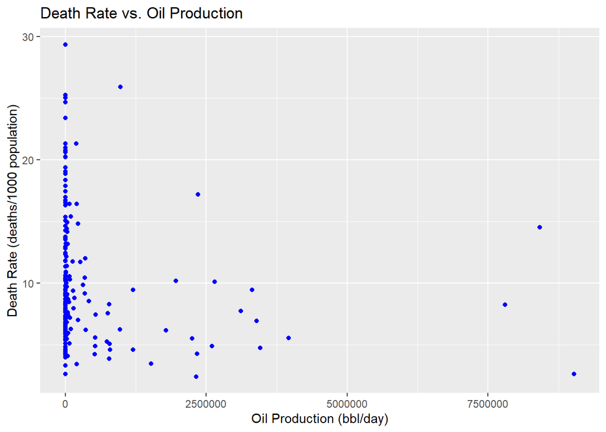

```r
factbook5_1 <- factbook %>% filter(!is.na(`Death rate(deaths/1000 population)`) & !is.na(`Oil - production(bbl/day)`))
ggplot(data = factbook5_1) + geom_point(aes(x= `Oil - production(bbl/day)`, y = `Death rate(deaths/1000 population)`), color = "blue") + labs(title = "Death Rate vs. Oil Production", x = "Oil Production (bbl/day)", y = "Death Rate (deaths/1000 population)")
```

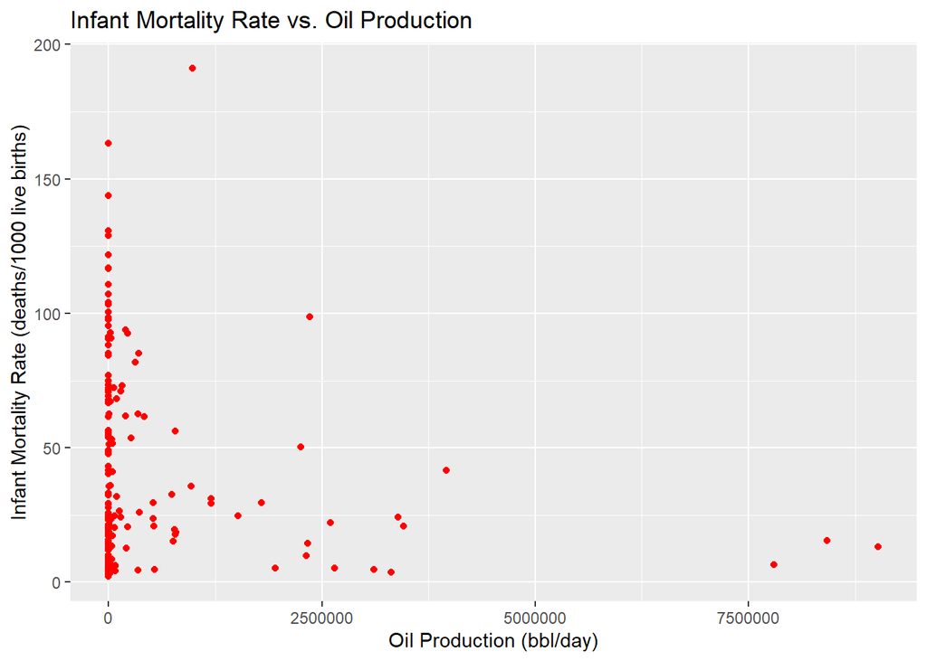

```r
factbook5_2 <- factbook %>% filter(!is.na(`Infant mortality rate(deaths/1000 live births)`) & !is.na(`Oil - production(bbl/day)`))
ggplot(data = factbook5_2)+ geom_point(aes(x= `Oil - production(bbl/day)`, y  = `Infant mortality rate(deaths/1000 live births)`), color = "red") + labs(title = "Infant Mortality Rate vs. Oil Production", x = "Oil Production (bbl/day)", y = "Infant Mortality Rate (deaths/1000 live births)")
```

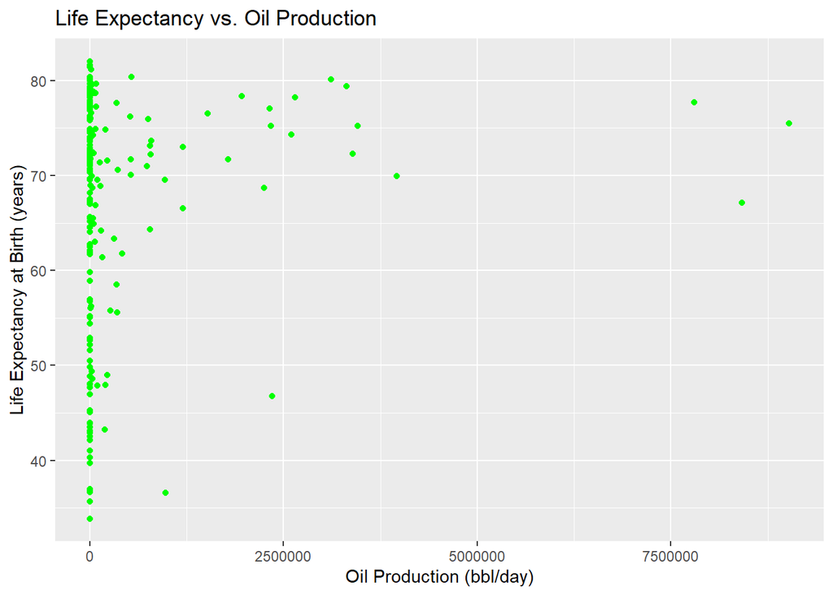

```r
factbook5_3 <- factbook %>% filter(!is.na(`Life expectancy at birth(years)`) & !is.na(`Oil - production(bbl/day)`))
ggplot(data = factbook5_3)+ geom_point(aes(x= `Oil - production(bbl/day)`, y  = `Life expectancy at birth(years)`), color = "green")+ labs(title = "Life Expectancy vs. Oil Production", x = "Oil Production (bbl/day)", y = "Life Expectancy at Birth (years)")
```

### Oil Consumption

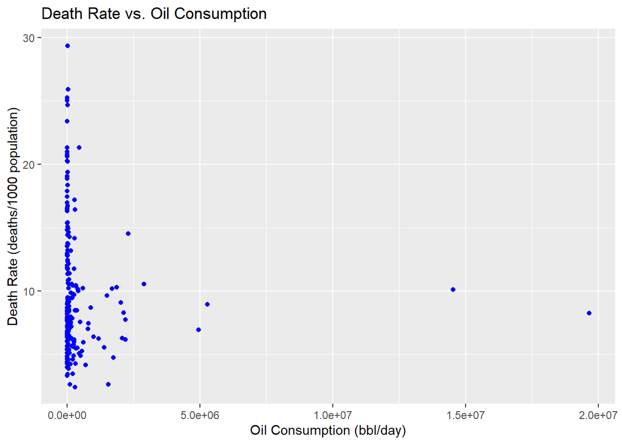

```r
factbook6_1 <- factbook %>% filter(!is.na(`Death rate(deaths/1000 population)`) & !is.na(`Oil - consumption(bbl/day)`))
ggplot(data = factbook6_1) + geom_point(aes(x= `Oil - consumption(bbl/day)`, y = `Death rate(deaths/1000 population)`), color = "blue") + labs(title = "Death Rate vs. Oil Consumption", x = "Oil Consumption (bbl/day)", y = "Death Rate (deaths/1000 population)")
```

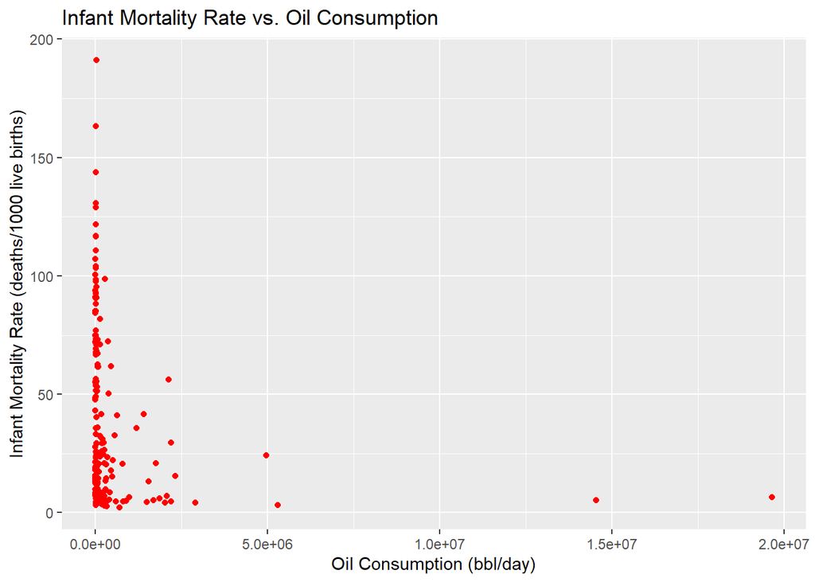

```r
factbook6_2 <- factbook %>% filter(!is.na(`Infant mortality rate(deaths/1000 live births)`) & !is.na(`Oil - consumption(bbl/day)`))
ggplot(data = factbook6_2) + geom_point(aes(x= `Oil - consumption(bbl/day)`, y  = `Infant mortality rate(deaths/1000 live births)`), color = "red") + labs(title = "Infant Mortality Rate vs. Oil Consumption", x = "Oil Consumption (bbl/day)", y = "Infant Mortality Rate (deaths/1000 live births)")
```

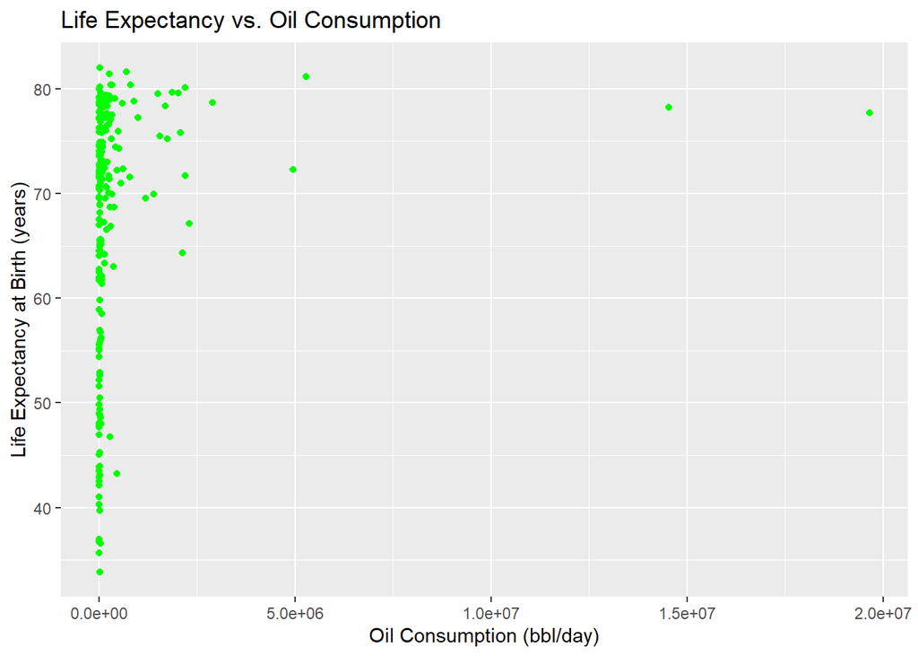

```r
factbook6_3 <- factbook %>% filter(!is.na(`Life expectancy at birth(years)`) & !is.na(`Oil - consumption(bbl/day)`))
ggplot(data = factbook6_3)+ geom_point(aes(x= `Oil - consumption(bbl/day)`, y  = `Life expectancy at birth(years)`), color = "green")+ labs(title = "Life Expectancy vs. Oil Consumption", x = "Oil Consumption (bbl/day)", y = "Life Expectancy at Birth (years)")
```

### Industrial Growth Rate

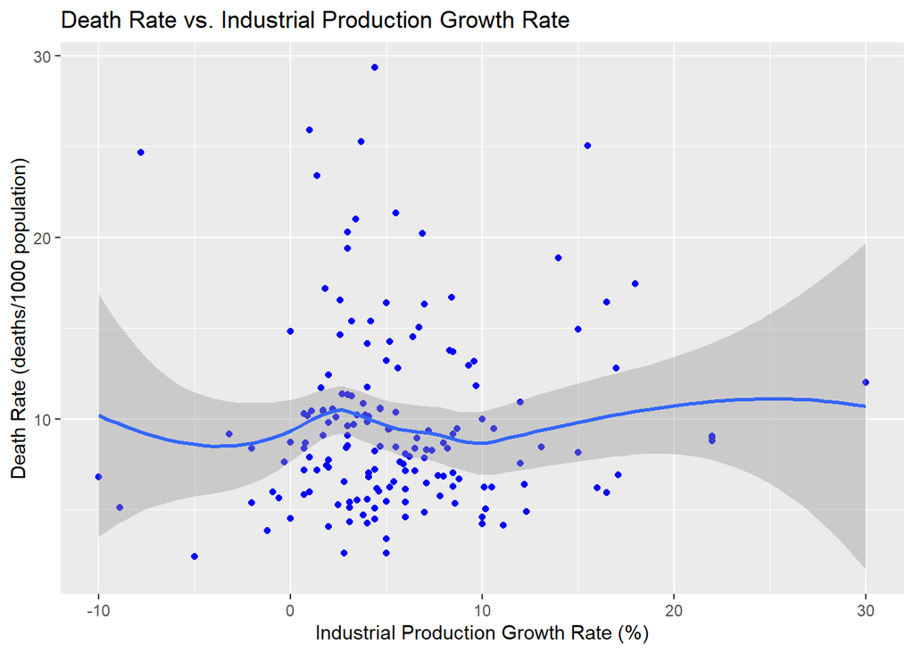

```r
factbook7_1 <- factbook %>% filter(!is.na(`Death rate(deaths/1000 population)`) & !is.na(`Industrial production growth rate(%)`))
ggplot(data = factbook7_1) + geom_point(mapping = aes(x =  `Industrial production growth rate(%)`, y = `Death rate(deaths/1000 population)`), color = "blue") +geom_smooth(mapping = aes(x =  `Industrial production growth rate(%)`, y = `Death rate(deaths/1000 population)`))+ labs(title = "Death Rate vs. Industrial Production Growth Rate", x = "Industrial Production Growth Rate (%)", y = "Death Rate (deaths/1000 population)")
```

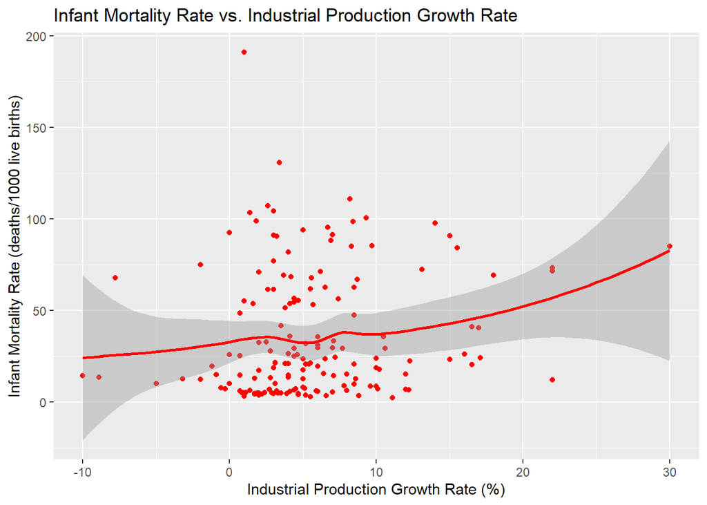

```r
factbook7_2 <- factbook %>% filter(!is.na(`Infant mortality rate(deaths/1000 live births)`) & !is.na(`Industrial production growth rate(%)`))
ggplot(data = factbook7_2) + geom_point(mapping = aes(x =  `Industrial production growth rate(%)`, y = `Infant mortality rate(deaths/1000 live births)`), color = "red")+ geom_smooth(mapping = aes(x =  `Industrial production growth rate(%)`, y = `Infant mortality rate(deaths/1000 live births)`), color = "red")+ labs(title = "Infant Mortality Rate vs. Industrial Production Growth Rate", x = "Industrial Production Growth Rate (%)", y = "Infant Mortality Rate (deaths/1000 live births)")
```

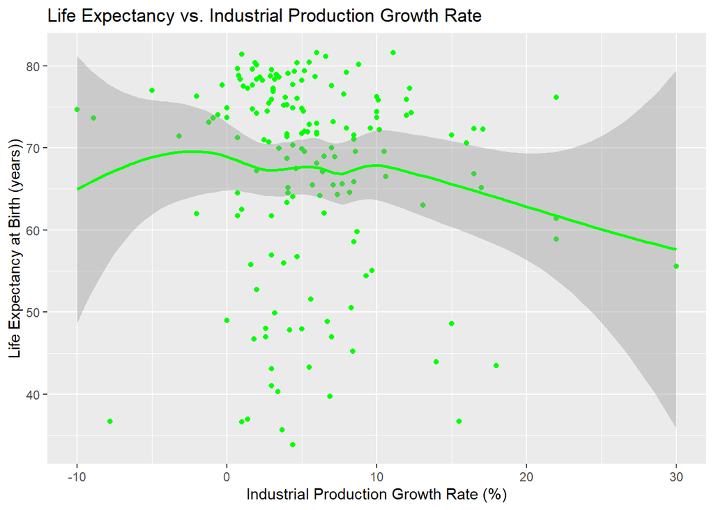

```r
factbook7_3 <- factbook %>% filter(!is.na(`Life expectancy at birth(years)`) & !is.na(`Industrial production growth rate(%)`))
ggplot(data = factbook7_3)+ geom_point(aes(x= `Industrial production growth rate(%)`, y  = `Life expectancy at birth(years)`), color = "green")+ geom_smooth(aes(x= `Industrial production growth rate(%)`, y  = `Life expectancy at birth(years)`), color = "green")+ labs(title = "Life Expectancy vs. Industrial Production Growth Rate", x = "Industrial Production Growth Rate (%)", y = "Life Expectancy at Birth (years))")
```

### Overall Conclusion and Recommendation:

All of the above graphs suggest little to no trend between levels of industrialization and overall population health. In some cases, there may be a minimal positive trend towards increasing a specific part of population health with increasing levels of industrial production in specific areas, but these positive trends are often contradicted by negative trends by other factors of population health, suggesting that these trends are more than likely outliers in the overall set of data. It is clear from all the above graphs that any increase in population health with incresaing levels of industrialization is caused by other factors not requested to be studied by the public health specialist. Therefore, we would recommend that no action be taken from the above data. There is simply no way to tell that any relationship exists between levels of industrialization and population health, and it would be incredibly foolhardy to then recommend action knowing this. We would, however, recommend that the public health specialist explore other factors that may have a greater impact on population health, such as level of GDP per capita and other factors related to economic prosperity in a country, as a higher level of economic prosperity is much more likely to indicate a country’s successin development, and is therefore much more likely to correlate stringly with population health. Industrialization is simply too varied in its levels across both developing and developed countries, and is just not a reliable measure of a country’s prosperity and overall population health.

## Brief Description of the dataset

The datset being used is a factbook with data on 160 countries, and ~100 non-country political entities. Across these countries it has 44 measurements, including debt, resource consumtion/production, internet users, life expectancy, fertility rates, and many more.

These data comes from the CIA, however they don’t provide an csv file download, so the actual csv file was obtained from https://perso.telecom-paristech.fr/eagan/class/igr204/datasets

# Codebook:

- Country=Name of country
- Area(sq km)=Country area in square kilometers
- Birth rate(births/1000 population)=Number of births in a year per 1000 people in country,
- Current account balance=Current account balance compares a country’s net trade in goods and services, plus net earnings, and net transfer payments to and from the rest of the world during the period specified. These figures are calculated on an exchange rate basis.
- Death rate(deaths/1000 population)=Deaths per year per 1000 population,
- Debt - external=Debt owed to creditors outside country,
- Electricity - consumption(kWh)=Electricity consumed by country kilowatt hours,
- Electricity - production(kWh)=Electricity produced in kilowatt hours,
- Exports=Total value of exports in USD,
- GDP=Gross domestic product in USD,
- GDP - per capita=GDP per person in USD,
- GDP - real growth rate(%)=Inflation adjusted rate of GDP growth per year,
- HIV/AIDS - adult prevalence rate(%)=Percent of Adults with HIV,
- HIV/AIDS - deaths=Number of deaths per year from HIV/AIDS,
- HIV/AIDS - people living with HIV/AIDS=Number of adults with HIV/AIDS,
- Highways(km)=Total length of highways in kilometers,
- Imports=Total value of imports in USD,
- Industrial production growth rate(%)=Industrial production growth rate compares the annual percentage increase in industrial production (includes manufacturing, mining, and construction).,
- Infant mortality rate(deaths/1000 live births)=Infant death per 1000 live births,
- Inflation rate (consumer prices)(%)=Rate of inflation in cost of consumer products,
- Internet hosts=Number of internet hosts in country,
- Internet users=Number of internet users in country,
- Investment (gross fixed)(% of GDP)=This entry records total business spending on fixed assets, such as factories, machinery, equipment, dwellings, and inventories of raw materials, which provide the basis for future production. It is measured gross of the depreciation of the assets, i.e., it includes investment that merely replaces worn-out or scrapped capital.,
- Labor force=This entry contains the total labor force figure.,
- Life expectancy at birth(years)=This entry contains the average number of years to be lived by a group of people born in the same year, if mortality at each age remains constant in the future. Life expectancy at birth is also a measure of overall quality of life in a country and summarizes the mortality at all ages. It can also be thought of as indicating the potential return on investment in human capital and is necessary for the calculation of various actuarial measures.,
- Military expenditures - dollar figure=total military expenditure,
- Military expenditures - percent of GDP(%)=This entry gives spending on defense programs for the most recent year available as a percent of gross domestic product (GDP); the GDP is calculated on an exchange rate basis, i.e., not in terms of purchasing power parity (PPP). For countries with no military forces, this figure can include expenditures on public security and police.,
- Natural Gas and Oil
  - consumption=amount of oil or natural gas consumed, cubic meters for natural gas, billion barrels/day for Oil
  - exports=amount sent to other countries, in same units
  - imports=amount brought in from other countries, in same units
  - production=amount produced
  - proved reserves=This entry is the stock of proved reserves of natural gas in cubic meters (cu m) or oil in billions of barrels. Proved reserves are those quantities of natural gas or oil, which, by analysis of geological and engineering data, can be estimated with a high degree of confidence to be commercially recoverable from a given date forward, from known reservoirs and under current economic conditions.
  - Natural gas - consumption(cu m)
  - Natural gas - exports(cu m)
  - Natural gas - imports(cu m)
  - Natural gas - production(cu m)
  - Natural gas - proved reserves(cu m)
  - Oil - consumption(bbl/day)
  - Oil - exports(bbl/day)
  - Oil - imports(bbl/day)
  - Oil - production(bbl/day)
  - Oil - proved reserves(bbl)
- Population=This entry gives an estimate from the US Bureau of the Census based on statistics from population censuses, vital statistics registration systems, or sample surveys pertaining to the recent past and on assumptions about future trends. The total population presents one overall measure of the potential impact of the country on the world and within its region. Note: Starting with the 1993 Factbook, demographic estimates for some countries (mostly African) have explicitly taken into account the effects of the growing impact of the HIV/AIDS epidemic. These countries are currently: The Bahamas, Benin, Botswana, Brazil, Burkina Faso, Burma, Burundi, Cambodia, Cameroon, Central African Republic, Democratic Republic of the Congo, Republic of the Congo, Cote d’Ivoire, Ethiopia, Gabon, Ghana, Guyana, Haiti, Honduras, Kenya, Lesotho, Malawi, Mozambique, Namibia, Nigeria, Rwanda, South Africa, Swaziland, Tanzania, Thailand, Togo, Uganda, Zambia, and Zimbabwe.,
- Railways(km)=This entry states the total route length of the railway network and of its component parts by gauge, which is the measure of the distance between the inner sides of the load-bearing rails. The four typical types of gauges are: broad, standard, narrow, and dual. Other gauges are listed under note. Some 60% of the world’s railways use the standard gauge of 1.4 m (4.7 ft). Gauges vary by country and sometimes within countries. The choice of gauge during initial construction was mainly in response to local conditions and the intent of the builder. Narrow-gauge railways were cheaper to build and could negotiate sharper curves, broad-gauge railways gave greater stability and permitted higher speeds. Standard-gauge railways were a compromise between narrow and broad gauges.,
- Public debt(% of GDP)=This entry records the cumulative total of all government borrowings less repayments that are denominated in a country’s home currency. Public debt should not be confused with external debt, which reflects the foreign currency liabilities of both the private and public sector and must be financed out of foreign exchange earnings.,
- Reserves of foreign exchange & gold=This entry gives the dollar value for the stock of all financial assets that are available to the central monetary authority for use in meeting a country’s balance of payments needs as of the end-date of the period specified. This category includes not only foreign currency and gold, but also a country’s holdings of Special Drawing Rights in the International Monetary Fund, and its reserve position in the Fund.,
- Telephones - main lines in use=This entry gives the total number of fixed telephone lines in use,
- Telephones - mobile cellular=This entry gives the total number of mobile cellular telephone subscribers,
- Total fertility rate(children born/woman)=This entry gives a figure for the average number of children that would be born per woman if all women lived to the end of their childbearing years and bore children according to a given fertility rate at each age. The total fertility rate (TFR) is a more direct measure of the level of fertility than the crude birth rate, since it refers to births per woman. This indicator shows the potential for population change in the country. A rate of two children per woman is considered the replacement rate for a population, resulting in relative stability in terms of total numbers. Rates above two children indicate populations growing in size and whose median age is declining. Higher rates may also indicate difficulties for families, in some situations, to feed and educate their children and for women to enter the labor force. Rates below two children indicate populations decreasing in size and growing older. Global fertility rates are in general decline and this trend is most pronounced in industrialized countries, especially Western Europe, where populations are projected to decline dramatically over the next 50 years.,
- Unemployment rate(%)=This entry contains the percent of the labor force that is without jobs. Substantial underemployment might be noted.

## Braden Griebel Individual Section:

**Question:** What is the relationship between length of highways and railroads, when controlling for land area and wealth measured by GDP per capita, and what affect does the ratio have with the oil consumption of the country?

Note that the countries were divided between the three categories based on the 33rd and 66th percentiles (1/3 and 2/3) of the Area of a country. So small countries were those with less than 3962.8 sq km, medium were between 3962.8 and 184848.8, and large were any countries that were larger than that. Small countries were mostly ancient cities and other outliers, with large numbers of NA for all the variables. Thus the data for small countries is not very useful, and mostly just eliminated from the rest of the data.

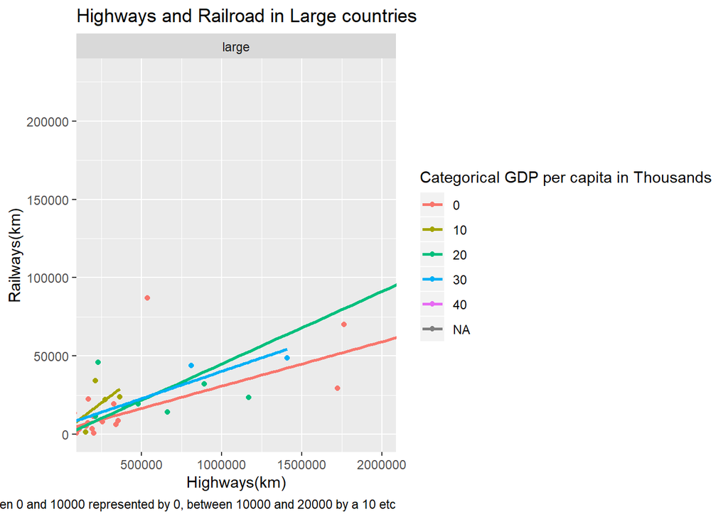

```r
bfactbook<-factbook%>%mutate("ratio"=`Railways(km)`/`Highways(km)`)%>%
  mutate("GDP_fac"=
  ifelse(`GDP - per capita`<=10000,0,
         ifelse(`GDP - per capita`>10000&`GDP - per capita`<=20000,10,
         ifelse(`GDP - per capita`>20000&`GDP - per capita`<=30000,20,
         ifelse(`GDP - per capita`>30000&`GDP - per capita`<=40000,30,
         ifelse(`GDP - per capita`>40000&`GDP - per capita`<=50000,40,
         ifelse(`GDP - per capita`>50000,50,NA)))))))%>%
  mutate("area_fac"=
           ifelse(`Area(sq km)`<= 3962.8,"small",
                  ifelse(`Area(sq km)`> 3962.8&`Area(sq km)`<=184848.8,"medium",
                         ifelse(`Area(sq km)`>184848.8,"large",NA))))

large<-bfactbook%>%filter(area_fac=="large")
medium<-bfactbook%>%filter(area_fac=="medium")
small<-bfactbook%>%filter(area_fac=="small")
ggplot(large)+geom_jitter(aes(`Highways(km)`,`Railways(km)`,color=as.factor(GDP_fac)))+
  facet_wrap(~area_fac)+
  geom_smooth(method=lm,aes(`Highways(km)`,`Railways(km)`,color=as.factor(GDP_fac)),se=F)+coord_cartesian(xlim=c(184848.8,2e+06))+
  labs(title='Highways and Railroad in Large countries',color="Categorical GDP per capita in Thousands",
       caption="GDP per capita between 0 and 10000 represented by 0, between 10000 and 20000 by a 10 etc")
```

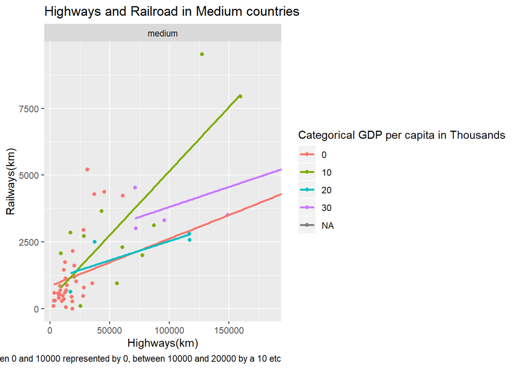

```r
ggplot(medium)+geom_jitter(aes(`Highways(km)`,`Railways(km)`,color=as.factor(GDP_fac)))+
  facet_wrap(~area_fac)+
  geom_smooth(method=lm,aes(`Highways(km)`,`Railways(km)`,color=as.factor(GDP_fac)),se=F)+coord_cartesian(xlim=c(3962.8,184848.8))+
  labs(title='Highways and Railroad in Medium countries',color="Categorical GDP per capita in Thousands",
       caption="GDP per capita between 0 and 10000 represented by 0, between 10000 and 20000 by a 10 etc")
```

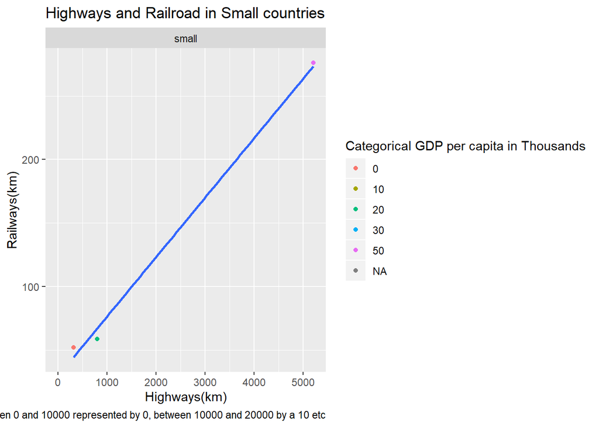

```r
ggplot(small)+geom_jitter(aes(`Highways(km)`,`Railways(km)`,color=as.factor(GDP_fac)))+
  facet_wrap(~area_fac)+
  geom_smooth(method=lm,aes(`Highways(km)`,`Railways(km)`),se=F)+#coord_cartesian(xlim=c(0,3962.8))+
  labs(title='Highways and Railroad in Small countries',color="Categorical GDP per capita in Thousands",
       caption="GDP per capita between 0 and 10000 represented by 0, between 10000 and 20000 by a 10 etc")
```

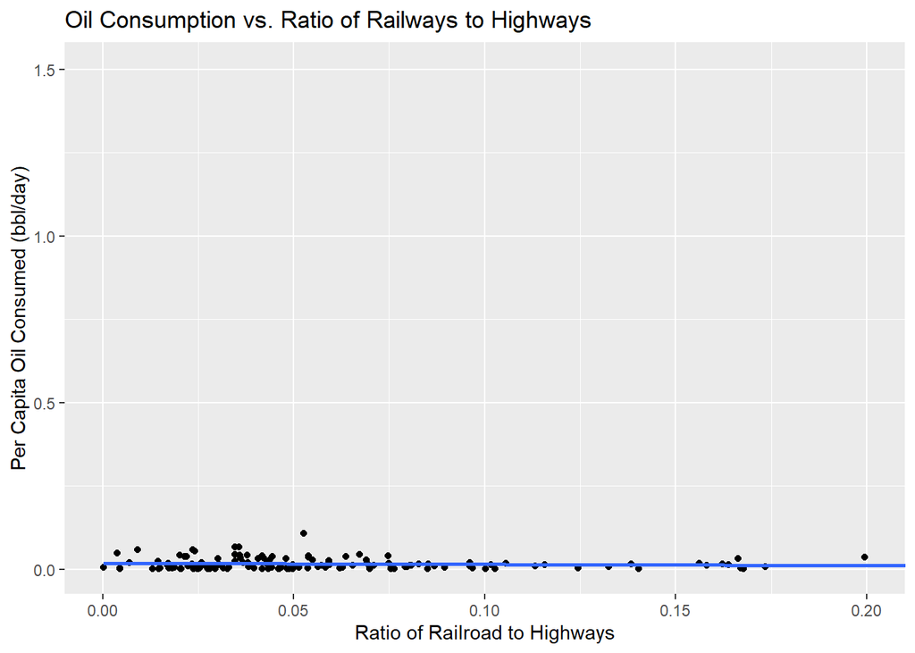

```r
bfactbook<-bfactbook%>%mutate("oil_percapita"=`Oil - consumption(bbl/day)`/Population)
ggplot(bfactbook,aes(ratio,oil_percapita))+geom_point()+geom_smooth(se=F,method=lm)+coord_cartesian(xlim=c(0,.2))+
labs(title="Oil Consumption vs. Ratio of Railways to Highways",x="Ratio of Railroad to Highways",y="Per Capita Oil Consumed (bbl/day)")
```

```r
bfb<-bfactbook%>%filter(!is.na(ratio)&!is.na(`oil_percapita`))
```

Correlation Between Ratio of Railways to Highways and Oil consumption in bbl/day

```r
cor(bfb$ratio,bfb$oil_percapita)
```

```
## [1] -0.1165541
```

### Findings:

From the graph directly above, and the correlation coefficient, there is no significant correlation between the ratio of railroads to higways. This could mean a variety of things, such as the effeciency of trains and highways not being significantly different, or usage rates varying not being reflected by size of the rail network. Either way this means it is not particularly useful to build more railways per km of highway in reducing oil use. From the first two graphs (again the third is for small countries and other territories, and in fact most of the countries have NAs across most of their variables), it can be seen that across GDP and country size there is a positive correlation between kilometers of highways in a country and kilometers of railways in a country. This makes sense, as both are correlated to country size. The slope of the lines varies between the GDP levels, but there doesn’t seem to be any consistant trends about what level of wealth leads to higher or lower slopes of the linear model. I would recomend an analyse that takes into account actual usage statistics of the railways, since that would allow for a better understanding of if trains are a good investment when seeking to reduce teh usage of fossil fuels. Additionally, data on the efficiency of trains versus trucks/cars in conveying people and goods should be undertaken in order to fully understand the relationship between the proportion of train usage and oil consumption.

## Ethics:

This analyse could hurt train companies that advertise their services based on the environmental impact of driving, since there seems to be no difference between countries with a high proportion of train lines to those with a low proportion of train lines. In the same way it could help car manufacturers by showing that more trains don’t necesarily reduce a countries oil consumption. Additionally, since the analysis doesn’t reflect actual train usage (since that was not in the dataset) I had to use a proxy for the usage (i.e. more kilometers of raillines means more train usage), which isn’t neccesarily well corelated with actual rail usage, which could mean that this analyses about the use of trains and oil consumption is inaccurate. This would in turn mean that people concerned about the environment who take trains for this reason might stop, which could cause an increase in oil consumption and thus CO2 released into the atmosphere, or that governments seeking to reduce carbon emissions would not invest in trains, so ultimately this analysis could cause the entire world to burn.

## Luke Fanning Individual Section

**Question:** How does the rate of military expenditures, in terms of percent of GDP, affect various measures of economic success, such as GDP growth rate, unemployment rate, public debt, as well as various import and export variables?

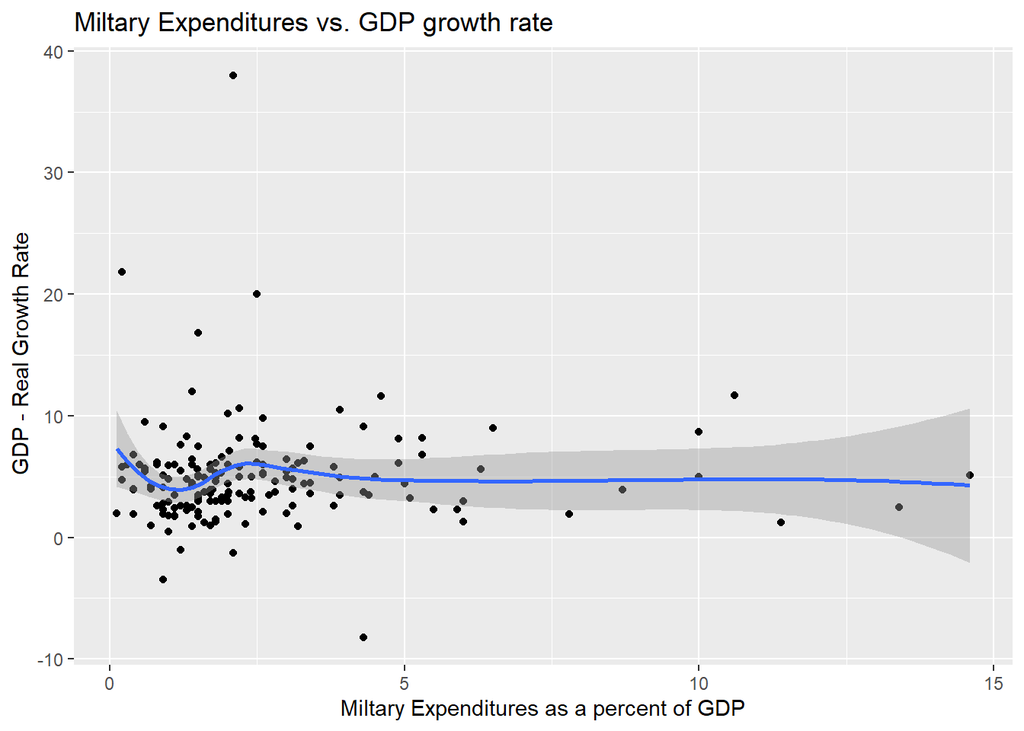

```r
l_1factbook <- factbook %>% filter(!is.na(`Military expenditures - percent of GDP(%)`) & !is.na(`GDP - real growth rate(%)`))

ggplot(data = l_1factbook, mapping = aes(x = `Military expenditures - percent of GDP(%)`, y = `GDP - real growth rate(%)`)) + geom_point() + geom_smooth() + labs(title = "Miltary Expenditures vs. GDP growth rate", x = "Miltary Expenditures as a percent of GDP", y = " GDP - Real Growth Rate")
```

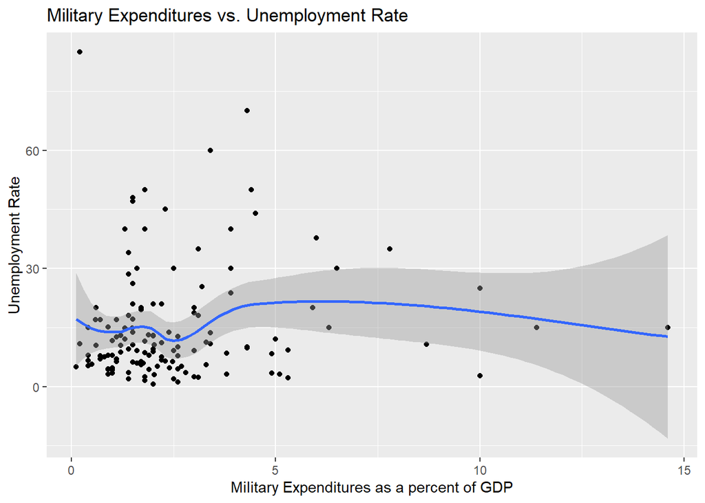

```r
l_2factbook <- factbook %>% filter(!is.na(`Military expenditures - percent of GDP(%)`) & !is.na(`Unemployment rate(%)`))

ggplot(data = l_2factbook, mapping = aes(x = `Military expenditures - percent of GDP(%)`, y = `Unemployment rate(%)`)) + geom_point() + geom_smooth() + labs(title = "Military Expenditures vs. Unemployment Rate", x = "Military Expenditures as a percent of GDP", y = "Unemployment Rate")
```

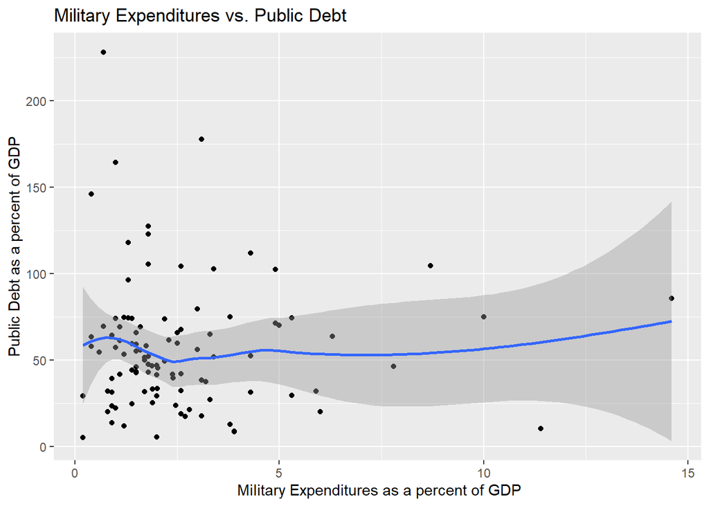

```r
l_3factbook <- factbook %>% filter(!is.na(`Military expenditures - percent of GDP(%)`) & !is.na(`Public debt(% of GDP)`))

ggplot(data = l_3factbook, mapping = aes(x = `Military expenditures - percent of GDP(%)`, y = `Public debt(% of GDP)`)) + geom_point() + geom_smooth() + labs(title = "Military Expenditures vs. Public Debt", x = " Military Expenditures as a percent of GDP", y = "Public Debt as a percent of GDP")
```

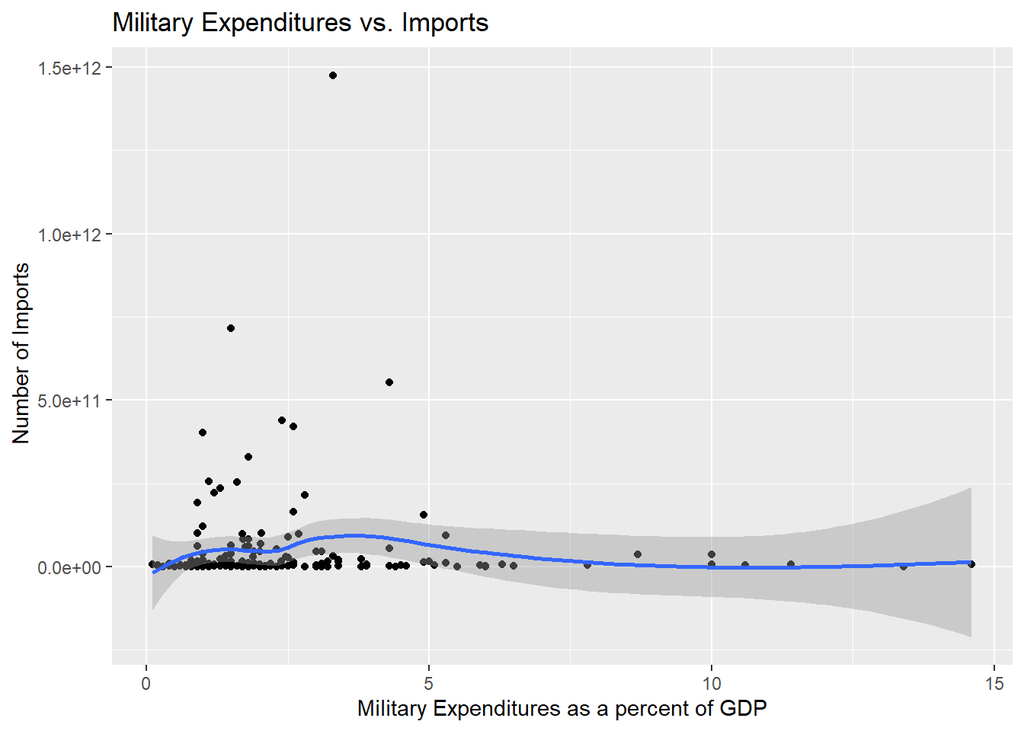

```r
l_4factbook <- factbook %>% filter(!is.na(`Military expenditures - percent of GDP(%)`) & !is.na(`Imports`))

ggplot(data = l_4factbook, mapping = aes(x = `Military expenditures - percent of GDP(%)`, y = `Imports`)) + geom_point() + geom_smooth() + labs(title = "Military Expenditures vs. Imports", x = "Military Expenditures as a percent of GDP", y = " Number of Imports")
```

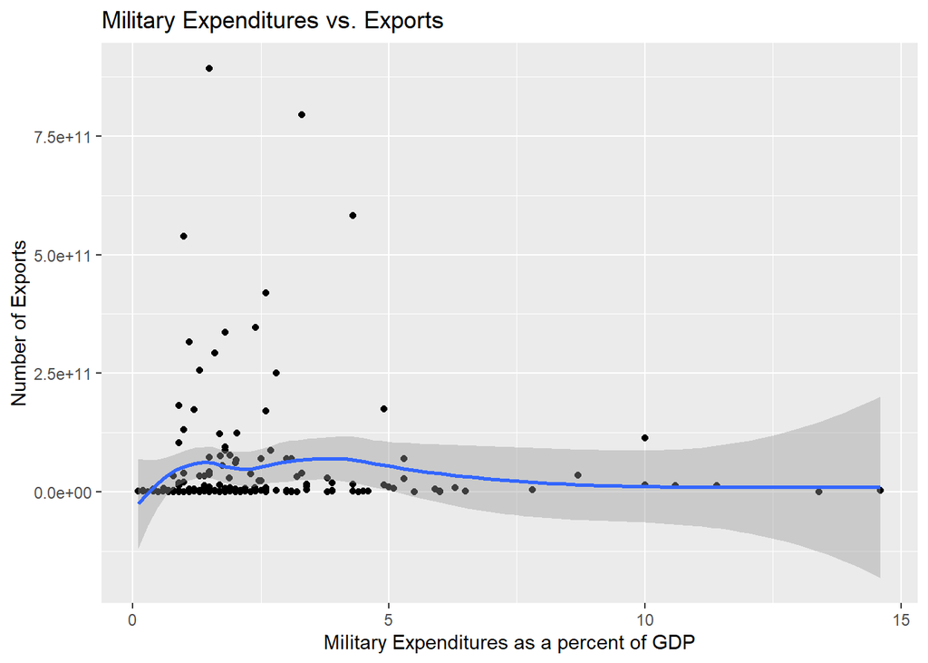

```r
l_5factbook <- factbook %>% filter(!is.na(`Military expenditures - percent of GDP(%)`) & !is.na(`Exports`))

ggplot(data = l_5factbook, mapping = aes(x = `Military expenditures - percent of GDP(%)`, y = `Exports`)) + geom_point() + geom_smooth() + labs(title = "Military Expenditures vs. Exports", x = "Military Expenditures as a percent of GDP", y = "Number of Exports")
```

### Findings:

The graphs above clearly show that there is no correlation between military spending as a function of GDP and any factor of economic success. This then means that countries looking to boost their economies in this day and age should focus on spending in other areas besides the military. This is especially relevant information to have in the US, where military spending has never been higher, yet we teeter closer and closer to a recession. One important thing to keep in mind with this data, however, is while there is no clear correlation between military expenditures and overall economic success, there is a correlation with decreased economic variability and military expenditures. This means that while you cannot necessary boost a country;s economy by spending money on the military, you can use military spending as a stabilizing factor to help reduce negative externalities of spending in other areas of the economy.

## Ahyo Falick Individual Section:

**Question 1** How does the percent of people in the labor force compared with the total population affect the industrial production growth rate? This is an interesting question because it might show correlations between a larger labor force and a high industrial production growth rate. The answer to this question could point to an ideal percent of workers in a country to optimize industrial production. From the data, it can be analyzed what percent of the population works for more industrialized countries and what percent works for less industrialized countries.

```r
labor <- factbook %>% select("Country","Labor force","Population","Industrial production growth rate(%)", "GDP - real growth rate(%)") %>% mutate(factbook$`Labor force` / factbook$Population * 100)
names(labor) <- c("Country", "Labor force", "Population", "Industrial production growth rate(%)", "GDP Growth Rate (%)", "Labor force (%)")
labor <- labor %>% filter(!is.na(labor$`Industrial production growth rate(%)`))
labor
```

```
## # A tibble: 164 x 6
##    Country `Labor force` Population `Industrial pro~ `GDP Growth Rat~
##    <chr>           <dbl>      <dbl>            <dbl>            <dbl>
##  1 Albania       1090000    3563112              3.1              5.6
##  2 Algeria       9910000   32531853              6                6.1
##  3 Angola        5410000   11190786              1               11.7
##  4 Anguil~          6049      13254              3.1              2.8
##  5 Antigu~         30000      68722              6                3
##  6 Argent~      15040000   39537943             12                8.3
##  7 Armenia       1400000    2982904             15                9
##  8 Austra~      10350000   20090437              1.9              3.5
##  9 Austria       3450000    8184691              3.3              1.9
## 10 Azerba~       5090000    7911974              4                9.8
## # ... with 154 more rows, and 1 more variable: `Labor force (%)` <dbl>
```

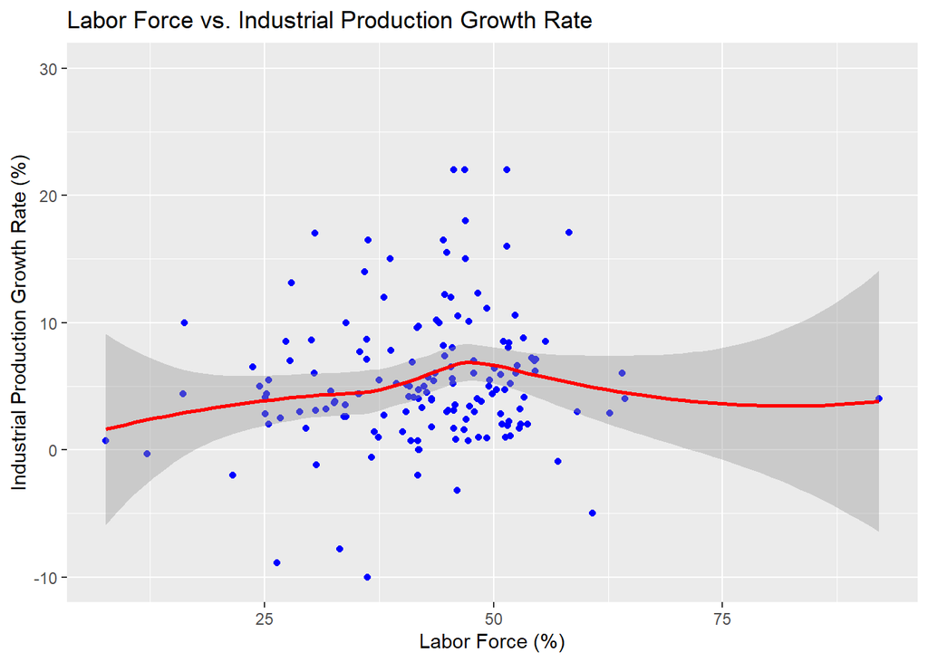

```r
ggplot(labor) + geom_point(mapping = aes(x = labor$`Labor force (%)`, y = labor$`Industrial production growth rate(%)`), color = "blue") + geom_smooth(mapping = aes(x = labor$`Labor force (%)`, y = labor$`Industrial production growth rate(%)`), color = "red") + labs(title = "Labor Force vs. Industrial Production Growth Rate", x = "Labor Force (%)", y = "Industrial Production Growth Rate (%)")
```

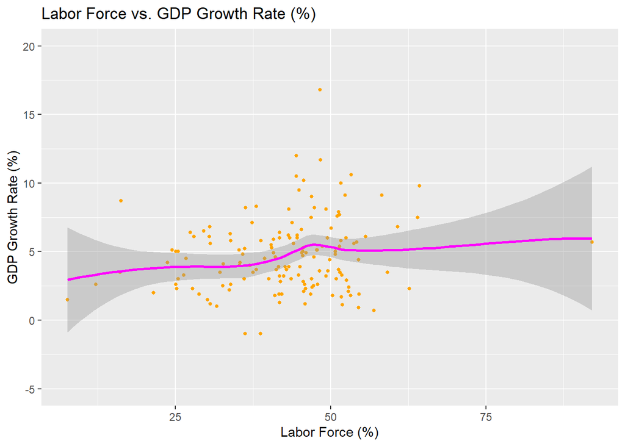

```r
ggplot(labor) + geom_point(mapping = aes(x = labor$`Labor force (%)`, y = labor$`GDP Growth Rate (%)`), color = "orange", size = 1) + geom_smooth(mapping = aes(x = labor$`Labor force (%)`, y = labor$`GDP Growth Rate (%)`), color = "magenta") + labs(title = "Labor Force vs. GDP Growth Rate (%)", x = "Labor Force (%)", y = "GDP Growth Rate (%)") + ylim(-5, 20)
```

### Findings:

The first graph compares the Labor Force percentage of a country with the its industrial production growth rate. The individual data points are depicted in blue and an attempted trend line is in red. From this data, it can be concluded that, to a certain extent, as the labor force increases, so does the growth rate of industrial production. The trend line steadily rises until nearly a 50% labor force, where the line begins to decrease. This demonstrates that there seems to be an ideal percentage of workers a country should have for the most industrial growth.

The second plot compares an increasing labor force percentage with a country’s gross domestic product (GDP). As with the industrial production growth rate, a country’s GDP growth rate increases steadily as the labor force percentage increases. The trendline for this graph increases throughout the whole graph with a slight decrease at 50%. The conclusion can therefore be drawn that the GDP growth rate has a positive correlation with an increased labor force. Furthermore, this shows that as long as the labor force is increasing, so will the GDP growth rate.

### Ethics Reflection:

This data can benefit countries with lower growth rates of industrial production and GDP by demonstrating that these rates can increase by establishing a larger labor force.

## Individual Contributions

Luke Fanning: I did my individual section and conclusion, answering my question through the use of geom_point and geom_smooth. I also used the dplyr function filter, allowing me to remove NA values from the dataset in order to create a more accurate depiction of the dataset. I also wrote out the team question, adding the necessary parts about implications of this data for the domain expert and deescribing why this dataset is just generally important in this day and age. I then completed all of the graphs for the team section, and wrote the findings for each section as well as the overall conclusion and recommendation.

Ahyo Falick: In order to complete my individual section, I first selected only the variables needed to compare labor force to growth rates. These variables were the country, the labor force, the population, the industrial production growth rate, and the GDP growth rate. In order to find the labor force as a percentage, I then divided the labor force of a country by the population of that country. Finally, I created two separate plots using geom_point and geom_smooth to display the data cleanly and show its trends.